# Regression Analysis: Is an Automatic or Manual Transmission better for MPG?

# Executive Summary

This report addresses the question of whether an automatic or manual transmission is better for MPG. In answering this question, I attempt to quantify any MPG difference between automatic and manual transmissions. After exploration and model fitting, I conclude that a manual transmission is better for MPG and the difference is signficant.

# Exploratory Analysis

#### Load All Necessary Packages

```r
suppressMessages(library(GGally))
suppressMessages(library(ggplot2))
library(printr)
library(car)
```

#### Data Description

A quick glance at the data set reveals the structure and the data available for our model.

```r
head(mtcars, n = 2)
```

|  | mpg | cyl | disp | hp | drat | wt | qsec | vs | am | gear | carb |
| --- | --- | --- | --- | --- | --- | --- | --- | --- | --- | --- | --- |
| Mazda RX4 | 21 | 6 | 160 | 110 | 3.9 | 2.620 | 16.46 | 0 | 1 | 4 | 4 |
| Mazda RX4 Wag | 21 | 6 | 160 | 110 | 3.9 | 2.875 | 17.02 | 0 | 1 | 4 | 4 |

```r
dim(mtcars)
```

```
## [1] 32 11
```

Looking at the mtcars help file, I can see what each of the variables means.

- mpg: miles/(US) gallon
- cyl: # of cylinders
- disp: displacement(cu. in.)
- hp: gross horsepower
- drat: rear axle ratio
- wt: weight(lb/1000)
- qsec: 1/4 mile time
- vs: V/S
- am: transmission (0 = automatic, 1 = manual)
- gear: # of forward gears
- carb: # of carburetors

First, let’s plot MPG by transmission and see if there is a difference visually.

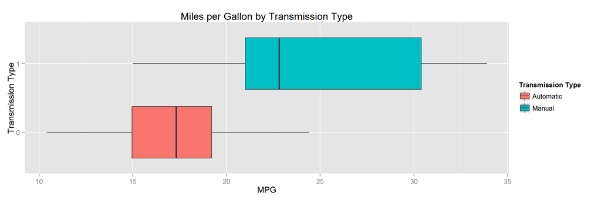

```r
ggplot(mtcars, aes(x = factor(am), y = mpg, fill = factor(am)))+
  geom_boxplot()+
  coord_flip()+
  xlab("Transmission Type")+
  ylab("MPG")+
  ggtitle("Miles per Gallon by Transmission Type")+
  scale_fill_discrete(name = "Transmission Type",
                      labels = c("Automatic", "Manual"))
```

Using the boxplot, my initial hypothesis is that there is a difference between the groups, with manual transmissions having higher MPG than automatic transmissions.

I perform a student’s T-Test to test for a statistically significant different between the means of the two groups–in this case automatic versus manual transmission. Our null hypothesis is that there is no difference between the means.

```r
t <- t.test(mtcars$mpg ~ factor(mtcars$am))
t
```

```
##
##  Welch Two Sample t-test
##
## data:  mtcars$mpg by factor(mtcars$am)
## t = -3.7671, df = 18.332, p-value = 0.001374
## alternative hypothesis: true difference in means is not equal to 0
## 95 percent confidence interval:
##  -11.280194  -3.209684
## sample estimates:
## mean in group 0 mean in group 1
##        17.14737        24.39231
```

With a p value of of 0.001 it is very unlikely a difference this large is due to chance.

#### Single Variable Linear Model

With the evidence in hand so far, let’s build a simple model using transmission as our lone variable.

```r
fit_am <- lm(mpg~ factor(am), mtcars)
summary(fit_am)
```

```
##
## Call:
## lm(formula = mpg ~ factor(am), data = mtcars)
##
## Residuals:
##     Min      1Q  Median      3Q     Max
## -9.3923 -3.0923 -0.2974  3.2439  9.5077
##
## Coefficients:
##             Estimate Std. Error t value Pr(>|t|)
## (Intercept)   17.147      1.125  15.247 1.13e-15 ***
## factor(am)1    7.245      1.764   4.106 0.000285 ***
## ---
## Signif. codes:  0 '***' 0.001 '**' 0.01 '*' 0.05 '.' 0.1 ' ' 1
##
## Residual standard error: 4.902 on 30 degrees of freedom
## Multiple R-squared:  0.3598, Adjusted R-squared:  0.3385
## F-statistic: 16.86 on 1 and 30 DF,  p-value: 0.000285
```

This simple model is interpreted with automatic transmission being the baseline. So the intercept of 17.147 is the mean mpg of cars with automatic transmissions.  
An am1 coefficient of 7.245 means a car, holding all else in the model constant, gets 7.245 mpg greater with a manual transmission.

With a p-value of .00029, this is a highly significant variable and seems to indicate transmission is a key variable in fuel efficiency. Looking at our adjusted r-squared, however, this model only explains 0.3384589 of the variation. Clearly, more explaination is needed to find a better model.

#### Multiple Variable Regression Model

```r
mfit1 <- lm(mpg ~ cyl+disp+hp+drat+wt+qsec+factor(vs)+factor(am)+gear+carb , mtcars)
summary(mfit1)
```

```
##
## Call:
## lm(formula = mpg ~ cyl + disp + hp + drat + wt + qsec + factor(vs) +
##     factor(am) + gear + carb, data = mtcars)
##
## Residuals:
##     Min      1Q  Median      3Q     Max
## -3.4506 -1.6044 -0.1196  1.2193  4.6271
##
## Coefficients:
##             Estimate Std. Error t value Pr(>|t|)
## (Intercept) 12.30337   18.71788   0.657   0.5181
## cyl         -0.11144    1.04502  -0.107   0.9161
## disp         0.01334    0.01786   0.747   0.4635
## hp          -0.02148    0.02177  -0.987   0.3350
## drat         0.78711    1.63537   0.481   0.6353
## wt          -3.71530    1.89441  -1.961   0.0633 .
## qsec         0.82104    0.73084   1.123   0.2739
## factor(vs)1  0.31776    2.10451   0.151   0.8814
## factor(am)1  2.52023    2.05665   1.225   0.2340
## gear         0.65541    1.49326   0.439   0.6652
## carb        -0.19942    0.82875  -0.241   0.8122
## ---
## Signif. codes:  0 '***' 0.001 '**' 0.01 '*' 0.05 '.' 0.1 ' ' 1
##
## Residual standard error: 2.65 on 21 degrees of freedom
## Multiple R-squared:  0.869,  Adjusted R-squared:  0.8066
## F-statistic: 13.93 on 10 and 21 DF,  p-value: 3.793e-07
```

We start by fitting a model with all variables. Looking at the summary, none of the variables are significant at the .05 level. However, this is probably due to correlation amongst the variables. It makes intuitive sense that variables like cyl and hp would be highly correlated. Looking at a pairs plot we can see the correlation of each variable.

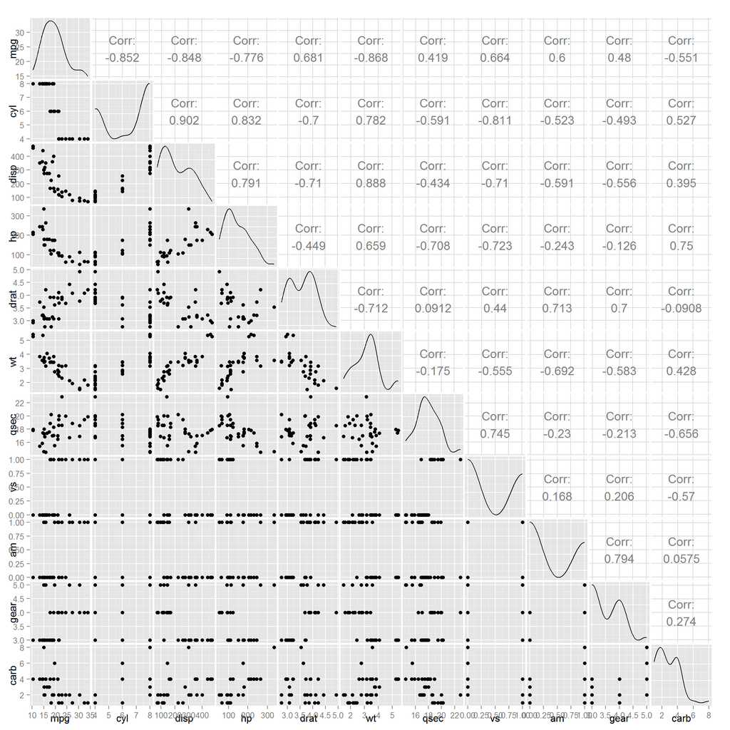

```r
ggpairs(mtcars)
```

We have significant collinearity. This can mislead as to the importance of predictors and can lead to imprecise coefficients. The recommended solution to this is removing variables which are in effect trying to do the same job.

The major decision in this analysis is which method to use for model variable selection. Generally, criterion-based methods are recommended over stepwise methods as they search over a wider space and don’t use hypothesis testing to choose between models.

```r
step <- step(mfit1, direction = 'both')
summary(step)
```

[output not shown]

We need to check our model assumptions before we can decide whether to trust our model. Residual plots in the appendix check for homoscedasticity, linearity, normality and outliers.

### Appendix

#### Figure A

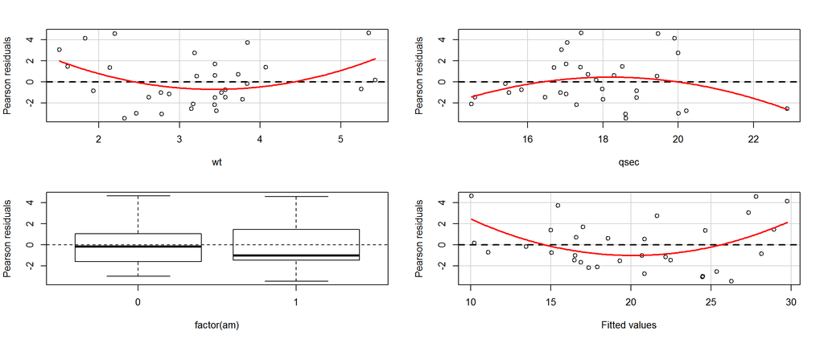

```r
par(mfrow = c(2,2))
residualPlots(step)
```

#### Figure B

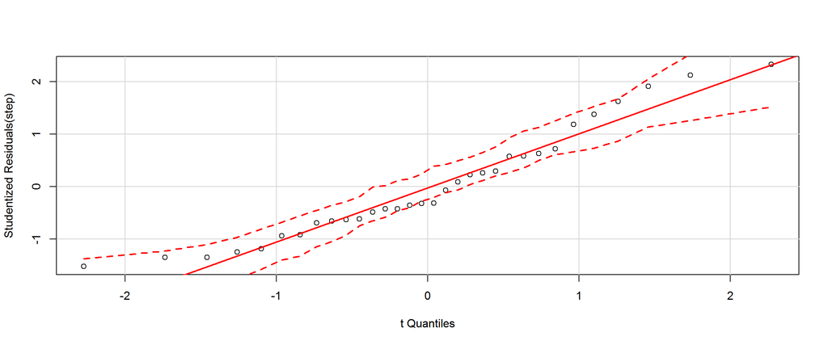

```r
qqPlot(step)
```

#### Figure C

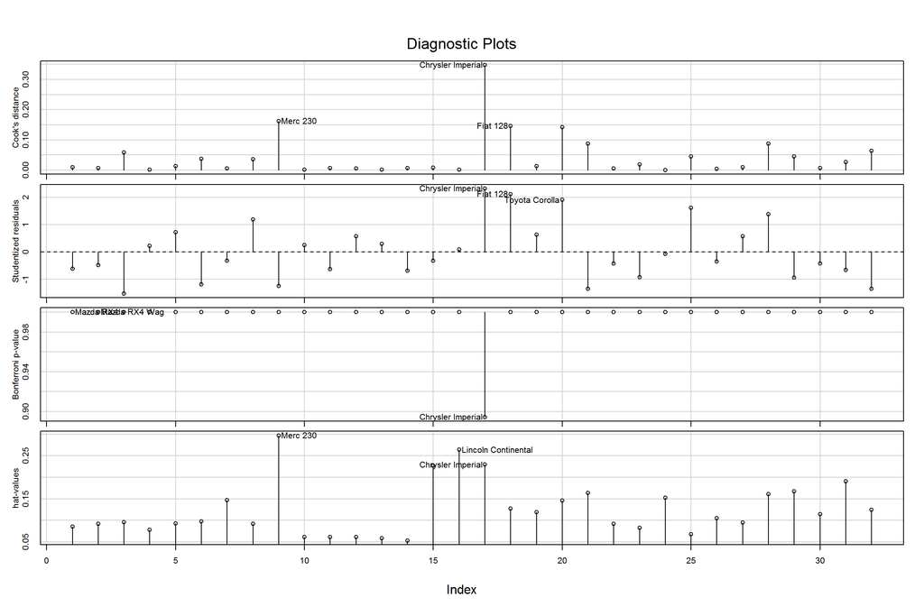

```r
influenceIndexPlot(step, id.n = 3)
```